# CRISP-DM (Cross Industry Standard Process for Data Mining)

### 1.Business Understanding

- What are the main federal highways?
- On which road do most accidents happen?
- What is the type of accident that happens the most?
- What month of the year has the most accidents?
- What time of day does most accidents happen?
- On which holiday does the most accident happen?
- In which km does the most accident happen on each road?

### 2.Data understanding

Open data from the Federal Government of Brazil recording accidents that occurred on federal highways.

https://www.gov.br/prf/pt-br/acesso-a-informacao/dados-abertos/dados-abertos-da-prf

### 3.Data Preparation

```python
# Imported libraries
from datetime import datetime
from IPython import display
import matplotlib.pyplot as plt
import numpy as np
import pandas as pd
import seaborn as sb
from sklearn.ensemble import GradientBoostingClassifier
from sklearn.linear_model import LogisticRegression
from sklearn.metrics import accuracy_score, fbeta_score, make_scorer
from sklearn.model_selection import train_test_split
from sklearn.model_selection import GridSearchCV
from sklearn.naive_bayes import GaussianNB
from time import time

import visuals as vs

%matplotlib inline
```

```python
# CSV files with data
# https://www.gov.br/prf/pt-br/acesso-a-informacao/dados-abertos/dados-abertos-da-prf
df_2021 = pd.read_csv('datatran2021.csv', sep = ';', encoding = 'ISO-8859-1')
df_2020 = pd.read_csv('datatran2020.csv', sep = ';', encoding = 'ISO-8859-1')
df_2019 = pd.read_csv('datatran2019.csv', sep = ';', encoding = 'ISO-8859-1')

df = pd.concat([df_2019, df_2020, df_2021])
```

```python
# Data from SPRF-DF
regional = 'SPRF-DF'
new_df = pd.DataFrame(data = (df[df['regional'] == regional]), columns = df.columns)
rows = new_df.shape[0]
columns = new_df.shape[1]
print(f'rows: {rows}\ncolumns: {columns}')
```

```
rows: 6259
columns: 30
```

```python
new_df.head(5)
```

|  | id | data_inversa | dia_semana | horario | uf | br | km | municipio | causa_acidente | tipo_acidente | ... | feridos_graves | ilesos | ignorados | feridos | veiculos | latitude | longitude | regional | delegacia | uop |
| --- | --- | --- | --- | --- | --- | --- | --- | --- | --- | --- | --- | --- | --- | --- | --- | --- | --- | --- | --- | --- | --- |
| 19 | 182528.0 | 2019-01-02 | quarta-feira | 10:30:00 | GO | 20.0 | 124,7 | FLORES DE GOIAS | Ultrapassagem Indevida | Tombamento | ... | 0 | 1 | 0 | 0 | 1 | -14,857715 | -46,79253 | SPRF-DF | DEL02-DF | UOP02-DEL02-DF |
| 54 | 183209.0 | 2019-01-03 | quinta-feira | 14:30:00 | GO | 40.0 | 51 | LUZIANIA | Defeito Mecânico no Veículo | Incêndio | ... | 0 | 1 | 0 | 0 | 1 | -16,450211 | -47,808134 | SPRF-DF | DEL01-DF | UOP04-DEL01-DF |
| 66 | 183266.0 | 2019-01-03 | quinta-feira | 17:30:00 | GO | 80.0 | 14 | PADRE BERNARDO | Falta de Atenção à Condução | Saída de leito carroçável | ... | 0 | 0 | 0 | 1 | 1 | -15,426183 | -48,195811 | SPRF-DF | DEL01-DF | UOP03-DEL01-DF |
| 126 | 183562.0 | 2019-01-05 | sábado | 11:30:00 | DF | 20.0 | 21 | BRASILIA | Velocidade Incompatível | Saída de leito carroçável | ... | 0 | 0 | 0 | 1 | 1 | -15,603384 | -47,684692 | SPRF-DF | DEL02-DF | UOP01-DEL02-DF |
| 185 | 183900.0 | 2019-01-07 | segunda-feira | 10:30:00 | GO | 20.0 | 5,7 | FORMOSA | Falta de Atenção à Condução | Colisão transversal | ... | 0 | 1 | 0 | 2 | 2 | -15,55123439 | -47,30253696 | SPRF-DF | DEL02-DF | UOP01-DEL02-DF |

5 rows × 30 columns

```python
new_df.info() # Number of entries (non-null)
```

```
<class 'pandas.core.frame.DataFrame'>
Int64Index: 6259 entries, 19 to 64524
Data columns (total 30 columns):
 #   Column                  Non-Null Count  Dtype
---  ------                  --------------  -----
 0   id                      6259 non-null   float64
 1   data_inversa            6259 non-null   object
 2   dia_semana              6259 non-null   object
 3   horario                 6259 non-null   object
 4   uf                      6259 non-null   object
 5   br                      6240 non-null   float64
 6   km                      6240 non-null   object
 7   municipio               6259 non-null   object
 8   causa_acidente          6259 non-null   object
 9   tipo_acidente           6258 non-null   object
```

[output cut: 22 more lines]

```python
(new_df.isna().sum()/new_df.shape[0]*100).sort_values(ascending=False)  # % Column NaN
```

```
br                        0.303563
km                        0.303563
uop                       0.079885
delegacia                 0.079885
tipo_acidente             0.015977
pessoas                   0.000000
regional                  0.000000
longitude                 0.000000
latitude                  0.000000
veiculos                  0.000000
feridos                   0.000000
ignorados                 0.000000
ilesos                    0.000000
feridos_graves            0.000000
feridos_leves             0.000000
mortos                    0.000000
id                        0.000000
uso_solo                  0.000000
data_inversa              0.000000
tipo_pista                0.000000
condicao_metereologica    0.000000
sentido_via               0.000000
fase_dia                  0.000000
classificacao_acidente    0.000000
causa_acidente            0.000000
municipio                 0.000000
uf                        0.000000
horario                   0.000000
dia_semana                0.000000
tracado_via               0.000000
dtype: float64
```

```python
new_df = new_df.dropna(how='any', axis=0) #Excluding lines that have NaN
```

```python
new_df.dtypes.sort_values() # Data type of each column
```

```
veiculos                    int64
feridos                     int64
ignorados                   int64
ilesos                      int64
feridos_graves              int64
feridos_leves               int64
mortos                      int64
pessoas                     int64
id                        float64
br                        float64
regional                   object
longitude                  object
latitude                   object
uso_solo                   object
tracado_via                object
tipo_pista                 object
condicao_metereologica     object
sentido_via                object
fase_dia                   object
classificacao_acidente     object
tipo_acidente              object
causa_acidente             object
municipio                  object
km                         object
uf                         object
horario                    object
dia_semana                 object
data_inversa               object
delegacia                  object
uop                        object
dtype: object
```

```python
new_df = new_df.astype({'id': 'str', 'br': 'str'}) # Transforming into categorical
```

```python
num_vars = new_df.select_dtypes(include=['float', 'int']).columns # Numerical
num_vars
```

```
Index(['pessoas', 'mortos', 'feridos_leves', 'feridos_graves', 'ilesos',
       'ignorados', 'feridos', 'veiculos'],
      dtype='object')
```

```python
cat_vars = new_df.select_dtypes(include=['object']).copy().columns # Categorical
cat_vars
```

```
Index(['id', 'data_inversa', 'dia_semana', 'horario', 'uf', 'br', 'km',
       'municipio', 'causa_acidente', 'tipo_acidente',
       'classificacao_acidente', 'fase_dia', 'sentido_via',
       'condicao_metereologica', 'tipo_pista', 'tracado_via', 'uso_solo',
       'latitude', 'longitude', 'regional', 'delegacia', 'uop'],
      dtype='object')
```

```python
for num in num_vars: # Counts of unique values in Numerical
    print(f'\nVal.     %    \n{new_df[num].value_counts() / new_df.shape[0]} \n')
```

```
Val.     %
2     0.434364
1     0.231447
3     0.173906
4     0.075653
5     0.041673
6     0.020516
7     0.009617
8     0.004808
9     0.002565
10    0.000962
12    0.000801
11    0.000641
26    0.000321
16    0.000321
```

[output cut: 118 more lines]

```python
for cat in cat_vars:  # Counts of unique values in Categorical
    print(f'\n{new_df[cat].value_counts() / new_df.shape[0]} \n')
```

```
182528.0    0.00016
327421.0    0.00016
328321.0    0.00016
328302.0    0.00016
328226.0    0.00016
             ...
256415.0    0.00016
256368.0    0.00016
256362.0    0.00016
256347.0    0.00016
462783.0    0.00016
Name: id, Length: 6239, dtype: float64


2020-10-09    0.003045
2019-12-06    0.002885
2021-02-07    0.002885
2019-08-24    0.002565
2019-04-21    0.002404
                ...
2019-04-26    0.000160
2020-09-28    0.000160
2020-10-08    0.000160
2021-03-29    0.000160
2019-01-24    0.000160
Name: data_inversa, Length: 1088, dtype: float64


domingo          0.177432
sábado           0.173425
sexta-feira      0.152589
quinta-feira     0.127585
segunda-feira    0.125020
terça-feira      0.123417
quarta-feira     0.120532
Name: dia_semana, dtype: float64


19:00:00    0.015868
07:00:00    0.012823
```

[output cut: 188 more lines]

```
Name: regional, dtype: float64


DEL01-DF    0.733771
DEL02-DF    0.266229
Name: delegacia, dtype: float64


UOP01-DEL01-DF    0.299567
UOP03-DEL01-DF    0.244430
UOP01-DEL02-DF    0.227280
UOP02-DEL01-DF    0.122616
UOP04-DEL01-DF    0.067158
UOP02-DEL02-DF    0.038949
Name: uop, dtype: float64
```

```python
# Dead victims or serious injuries will be graded as higher severity
def serious(df):
    if df['mortos'] > 0:
        return 1
    if df['feridos_graves'] > 0:
        return 1
    else:
        return 0

new_df['serious'] = new_df.apply(serious, axis=1)
```

```python
# Standardizing the dates
new_df['data_inversa'] = pd.to_datetime(new_df['data_inversa'], infer_datetime_format=True)
new_df = new_df.astype({'data_inversa': 'str'})
```

```python
new_df['dia'] = new_df['data_inversa'].apply(lambda x: x[-2:]) # Day
new_df['mes'] = new_df['data_inversa'].apply(lambda x: x[-5:-3]) # Month
new_df['ano'] = new_df['data_inversa'].apply(lambda x: x[:-6]) # Year
```

```python
# Identifying the dates that are national holidays in Brazil

# Holidays that always fall on the same date
c_universal = '01-01'
tiradentes = '04-21'
dm_trabalho = '05-01'
independencia = '09-07'
ns_aparecida = '10-12'
s_publico = '10-28'
finados = '11-02'
p_republica = '11-15'
v_natal = '12-24'
natal = '12-25'
a_novo = '12-31'

# Holidays that fall on different dates each year
carnaval21 = ['15', '16', '17'] # Month 02
carnaval20 = ['24', '25', '26'] # Month 02
carnaval19 = ['04', '05', '06'] # Month 03

paixaocristo21 = '02' # Month 04
paixaocristo20 = '10' # Month 04
paixaocristo19 = '19' # Month 04

corpuschristi21 = '03' # Month 06
corpuschristi20 = '11' # Month 06
corpuschristi19 = '20' # Month 06

def holiday(new_df):
    if new_df['mes'] == '01':
        if new_df['dia'] == c_universal[-2:]:
            return 'c_universal'
    if new_df['mes'] == '02':
        if new_df['ano'] == '21':
            if new_df['dia'] in carnaval21:
                return 'carnaval'
        if new_df['ano'] == '20':
            if new_df['dia'] in carnaval20:
                return 'carnaval'
    if new_df['mes'] == '03':
        if new_df['ano'] == '20':
            if new_df['dia'] in carnaval19:
                return 'carnaval'
    if new_df['mes'] == '04':
        if new_df['dia'] == tiradentes[-2:]:
            return 'tiradentes'
        if new_df['ano'] == '21':
            if new_df['dia'] == paixaocristo21[-2:]:
                return 'paixaocristo'
        if new_df['ano'] == '20':
            if new_df['dia'] == paixaocristo20[-2:]:
                return 'paixaocristo'
        if new_df['ano'] == '19':
            if new_df['dia'] == paixaocristo19[-2:]:
                return 'paixaocristo'
    if new_df['mes'] == '05':
        if new_df['dia'] == dm_trabalho[-2:]:
            return 'dm_trabalho'
    if new_df['mes'] == '06':
        if new_df['ano'] == '21':
            if new_df['dia'] == corpuschristi21[-2:]:
                return 'corpuschristi'
        if new_df['ano'] == '20':
            if new_df['dia'] == corpuschristi20[-2:]:
                return 'corpuschristi'
        if new_df['ano'] == '19':
            if new_df['dia'] == corpuschristi19[-2:]:
                return 'corpuschristi'
    if new_df['mes'] == '09':
        if new_df['dia'] == independencia[-2:]:
            return 'independencia'
    if new_df['mes'] == '10':
        if new_df['dia'] == ns_aparecida[-2:]:
            return 'ns_aparecida'
        if new_df['dia'] == s_publico[-2:]:
            return 's_publico'
    if new_df['mes'] == '11':
        if new_df['dia'] == finados[-2:]:
            return 'finados'
        if new_df['dia'] == p_republica[-2:]:
            return 'p_republica'
    if new_df['mes'] == '12':
        if new_df['dia'] == v_natal[-2:]:
            return 'v_natal'
        if new_df['dia'] == natal[-2:]:
            return 'natal'
        if new_df['dia'] == a_novo[-2:]:
            return 'a_novo'
        else:
            return 'normal_day'
    else:
        return 'normal_day'

new_df['holiday'] = new_df.apply(holiday, axis=1)
```

```python
total_years = len(new_df['ano'].value_counts()) # Total years
```

```python
avg_holiday = new_df['holiday'].value_counts()[1:] / total_years # Average accident per year
avg_holiday
```

```
c_universal      9.000000
tiradentes       8.333333
independencia    8.000000
finados          6.333333
dm_trabalho      5.333333
ns_aparecida     5.333333
p_republica      5.333333
v_natal          5.333333
a_novo           5.000000
natal            4.666667
s_publico        4.000000
Name: holiday, dtype: float64
```

```python
# Identifying the weekends
def weekend(new_df):
    if new_df['dia_semana'] in ['sábado', 'domingo']:
        return 'weekend'
    else:
        return 'weekday'

new_df['week'] = new_df.apply(weekend, axis=1)
```

```python
new_df[new_df['holiday'] == 'normal_day']['week'].value_counts() / (new_df['holiday'] == 'normal_day').shape[0]
```

```
weekday    0.625581
weekend    0.342363
Name: week, dtype: float64
```

```python
new_df[new_df['holiday'] != 'normal_day']['week'].value_counts() / (new_df['holiday'] != 'normal_day').shape[0]
```

```
weekday    0.023561
weekend    0.008495
Name: week, dtype: float64
```

```python
# off-holiday accidents
no_holiday = new_df[new_df['holiday'] == 'normal_day']['week']
no_hol_weekday = no_holiday.value_counts()[0] / total_years
no_hol_weekend = no_holiday.value_counts()[1] / total_years
```

### Death or serious injury

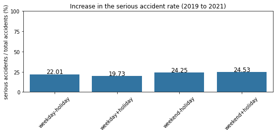

```python
# graves ou óbitos nos final de semana sem feriado
wkd = new_df[new_df['week'] == 'weekend']
wkd_nor = wkd[wkd['holiday'] == 'normal_day']['serious'].value_counts() * 100 / wkd[wkd['holiday'] =='normal_day'].shape[0]

# graves ou óbitos nos final de semana com feriado
wkd_hol = wkd[wkd['holiday'] != 'normal_day']['serious'].value_counts() * 100 / wkd[wkd['holiday'] != 'normal_day'].shape[0]

# graves ou óbitos semana sem feriado (seg a sex)
wk = new_df[new_df['week'] == 'weekday']
wk_nor = wk[wk['holiday'] == 'normal_day']['serious'].value_counts() * 100 / wk[wk['holiday'] == 'normal_day'].shape[0]

# graves ou óbitos semana com feriado (seg a sex)
wk_hol = wk[wk['holiday'] != 'normal_day']['serious'].value_counts() * 100 / wk[wk['holiday'] != 'normal_day'].shape[0]

x = ['weekday-holiday', 'weekday+holiday', 'weekend-holiday', 'weekend+holiday']
y = [wk_nor[1], wk_hol[1], wkd_nor[1], wkd_hol[1]]
df_ds = pd.DataFrame({'x': x, 'y': y})
base_color = sb.color_palette()[0]
plt.figure(figsize=(9, 3))
plot = sb.barplot(data=df_ds, y='y', x='x', color=base_color)
plt.yticks([0, 25, 50, 75, 100])
plt.xticks(rotation=45)
plt.title('Increase in the serious accident rate (2019 to 2021)')
plt.xlabel('')
plt.ylabel('serious accidents / total accidents (%)')
for i in plot.patches:
    plot.annotate(f'{i.get_height():.2f}',
                  (i.get_x() + i.get_width() / 2, i.get_height()),
                  ha='center',
                  va='baseline',
                  fontsize=12,
                  color='black',
                  xytext=(0, 1),
                  textcoords='offset points')
plt.show();
```

```python
# Divide the day into 24 hours
def hour(new_df):
    if datetime.strptime('00:00:00', '%H:%M:%S') <= datetime.strptime(new_df['horario'], '%H:%M:%S') <= datetime.strptime('00:59:59', '%H:%M:%S'):
        return '00:00:00'
    if datetime.strptime('01:00:00', '%H:%M:%S') <= datetime.strptime(new_df['horario'], '%H:%M:%S') <= datetime.strptime('01:59:59', '%H:%M:%S'):
        return '01:00:00'
    if datetime.strptime('02:00:00', '%H:%M:%S') <= datetime.strptime(new_df['horario'], '%H:%M:%S') <= datetime.strptime('02:59:59', '%H:%M:%S'):
        return '02:00:00'
    if datetime.strptime('03:00:00', '%H:%M:%S') <= datetime.strptime(new_df['horario'], '%H:%M:%S') <= datetime.strptime('03:59:59', '%H:%M:%S'):
        return '03:00:00'
    if datetime.strptime('04:00:00', '%H:%M:%S') <= datetime.strptime(new_df['horario'], '%H:%M:%S') <= datetime.strptime('04:59:59', '%H:%M:%S'):
        return '04:00:00'
    if datetime.strptime('05:00:00', '%H:%M:%S') <= datetime.strptime(new_df['horario'], '%H:%M:%S') <= datetime.strptime('05:59:59', '%H:%M:%S'):
        return '05:00:00'
    if datetime.strptime('06:00:00', '%H:%M:%S') <= datetime.strptime(new_df['horario'], '%H:%M:%S') <= datetime.strptime('06:59:59', '%H:%M:%S'):
        return '06:00:00'
    if datetime.strptime('07:00:00', '%H:%M:%S') <= datetime.strptime(new_df['horario'], '%H:%M:%S') <= datetime.strptime('07:59:59', '%H:%M:%S'):
        return '07:00:00'
    if datetime.strptime('08:00:00', '%H:%M:%S') <= datetime.strptime(new_df['horario'], '%H:%M:%S') <= datetime.strptime('08:59:59', '%H:%M:%S'):
        return '08:00:00'
    if datetime.strptime('09:00:00', '%H:%M:%S') <= datetime.strptime(new_df['horario'], '%H:%M:%S') <= datetime.strptime('09:59:59', '%H:%M:%S'):
        return '09:00:00'
    if datetime.strptime('10:00:00', '%H:%M:%S') <= datetime.strptime(new_df['horario'], '%H:%M:%S') <= datetime.strptime('10:59:59', '%H:%M:%S'):
        return '10:00:00'
    if datetime.strptime('11:00:00', '%H:%M:%S') <= datetime.strptime(new_df['horario'], '%H:%M:%S') <= datetime.strptime('11:59:59', '%H:%M:%S'):
        return '11:00:00'
    if datetime.strptime('12:00:00', '%H:%M:%S') <= datetime.strptime(new_df['horario'], '%H:%M:%S') <= datetime.strptime('12:59:59', '%H:%M:%S'):
        return '12:00:00'
    if datetime.strptime('13:00:00', '%H:%M:%S') <= datetime.strptime(new_df['horario'], '%H:%M:%S') <= datetime.strptime('13:59:59', '%H:%M:%S'):
        return '13:00:00'
    if datetime.strptime('14:00:00', '%H:%M:%S') <= datetime.strptime(new_df['horario'], '%H:%M:%S') <= datetime.strptime('14:59:59', '%H:%M:%S'):
        return '14:00:00'
    if datetime.strptime('15:00:00', '%H:%M:%S') <= datetime.strptime(new_df['horario'], '%H:%M:%S') <= datetime.strptime('15:59:59', '%H:%M:%S'):
        return '15:00:00'
    if datetime.strptime('16:00:00', '%H:%M:%S') <= datetime.strptime(new_df['horario'], '%H:%M:%S') <= datetime.strptime('16:59:59', '%H:%M:%S'):
        return '16:00:00'
    if datetime.strptime('17:00:00', '%H:%M:%S') <= datetime.strptime(new_df['horario'], '%H:%M:%S') <= datetime.strptime('17:59:59', '%H:%M:%S'):
        return '17:00:00'
    if datetime.strptime('18:00:00', '%H:%M:%S') <= datetime.strptime(new_df['horario'], '%H:%M:%S') <= datetime.strptime('18:59:59', '%H:%M:%S'):
        return '18:00:00'
    if datetime.strptime('19:00:00', '%H:%M:%S') <= datetime.strptime(new_df['horario'], '%H:%M:%S') <= datetime.strptime('19:59:59', '%H:%M:%S'):
        return '19:00:00'
    if datetime.strptime('20:00:00', '%H:%M:%S') <= datetime.strptime(new_df['horario'], '%H:%M:%S') <= datetime.strptime('20:59:59', '%H:%M:%S'):
        return '20:00:00'
    if datetime.strptime('21:00:00', '%H:%M:%S') <= datetime.strptime(new_df['horario'], '%H:%M:%S') <= datetime.strptime('21:59:59', '%H:%M:%S'):
        return '21:00:00'
    if datetime.strptime('22:00:00', '%H:%M:%S') <= datetime.strptime(new_df['horario'], '%H:%M:%S') <= datetime.strptime('22:59:59', '%H:%M:%S'):
        return '22:00:00'
    if datetime.strptime('23:00:00', '%H:%M:%S') <= datetime.strptime(new_df['horario'], '%H:%M:%S') <= datetime.strptime('23:59:59', '%H:%M:%S'):
        return '23:00:00'

new_df['hour'] = new_df.apply(hour, axis=1)
```

```python
new_df['hour'].value_counts() # Times with the most accidents
```

```
07:00:00    478
19:00:00    475
18:00:00    457
17:00:00    387
06:00:00    342
20:00:00    340
16:00:00    330
08:00:00    322
14:00:00    293
15:00:00    287
21:00:00    261
13:00:00    259
22:00:00    239
09:00:00    231
11:00:00    227
12:00:00    216
10:00:00    198
23:00:00    186
05:00:00    176
01:00:00    123
00:00:00    121
04:00:00    110
02:00:00     98
03:00:00     83
Name: hour, dtype: int64
```

```python
# Standardizing the Km
fill_int = lambda x: int(float(x.replace(',', '.')))
new_df['km'] = new_df['km'].apply(fill_int)
```

```python
new_df.dtypes.sort_values()
```

```
mortos                     int64
feridos_graves             int64
ilesos                     int64
ignorados                  int64
feridos                    int64
veiculos                   int64
pessoas                    int64
feridos_leves              int64
km                         int64
serious                    int64
delegacia                 object
longitude                 object
latitude                  object
dia                       object
mes                       object
ano                       object
holiday                   object
uop                       object
regional                  object
id                        object
uso_solo                  object
data_inversa              object
dia_semana                object
horario                   object
uf                        object
br                        object
municipio                 object
week                      object
causa_acidente            object
classificacao_acidente    object
fase_dia                  object
sentido_via               object
condicao_metereologica    object
tipo_pista                object
tracado_via               object
tipo_acidente             object
hour                      object
dtype: object
```

```python
new_df = new_df.astype({'km': 'str'}) # Turning into categorical
```

```python
df_remove = new_df.loc[(new_df['br'] == '10.0') | (new_df['br'] == '457.0')] # Removing these two BR. Doesn't seem to be from the DF
new_df = new_df.drop(df_remove.index)
```

### Cumulative amount of accidents each month (2019 to 2021)

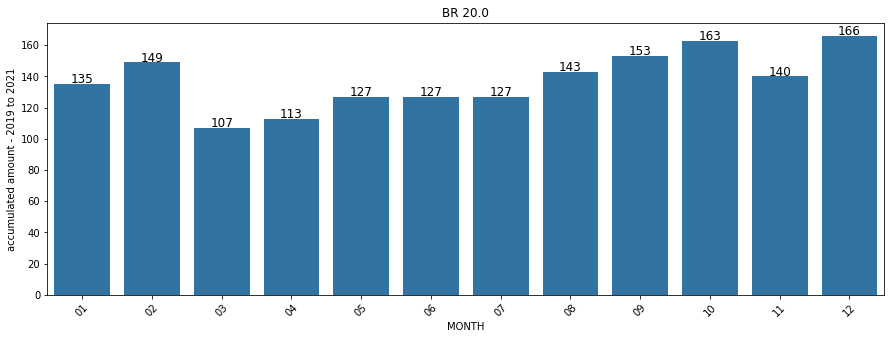

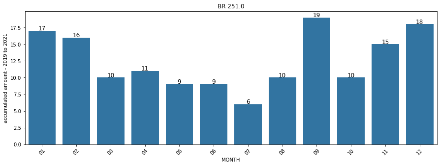

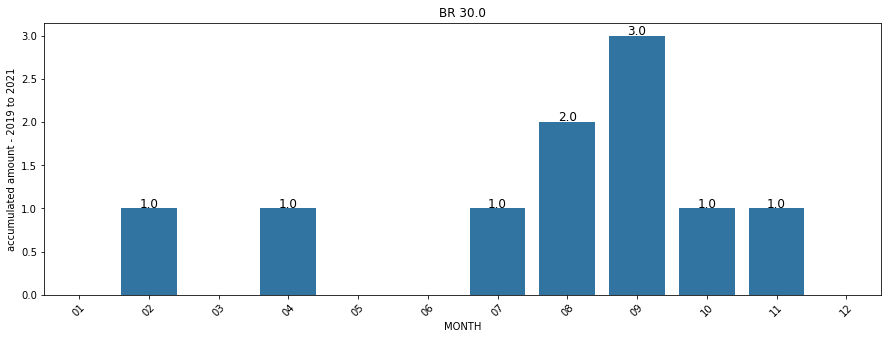

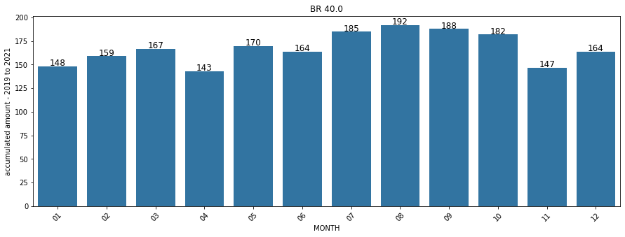

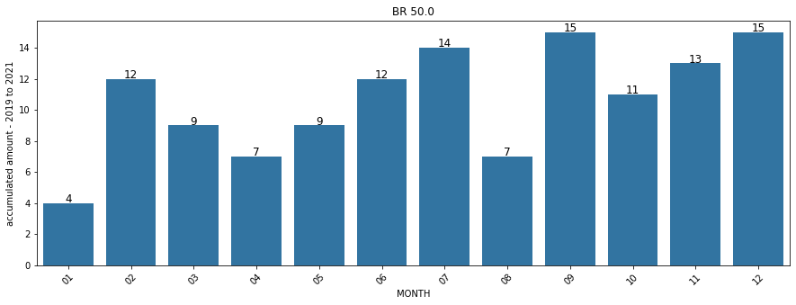

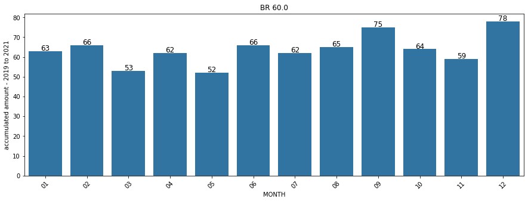

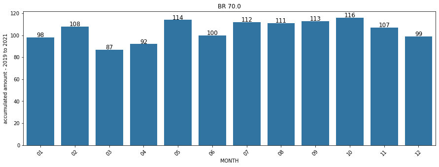

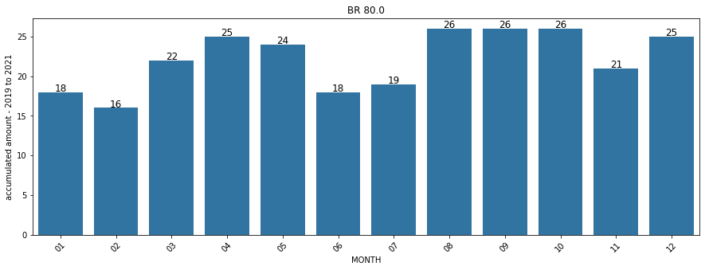

```python
# Cumulative amount of accidents each month x BR
base_color = sb.color_palette()[0]
lista_br = new_df['br'].value_counts().index.sort_values()
lista_mes = {'01': 'janeiro', '02': 'fevereiro', '03': 'marco', '04': 'abril', '05': 'maio', '06': 'junho',
             '07': 'julho', '08': 'agosto', '09': 'setembro', '10': 'outubro', '11': 'novembro', '12': 'dezembro'}
for br in lista_br:
    valor = new_df[new_df['br'] == br]
    plt.figure(figsize=(15, 5))
    plot = sb.countplot(data=valor, x='mes', order=lista_mes, color=base_color)
    plt.xticks(rotation=45)
    plt.title(f'BR {br}')
    plt.xlabel('MONTH')
    plt.ylabel('accumulated amount - 2019 to 2021')
    for i in plot.patches:
        plot.annotate(i.get_height(),
                      (i.get_x() + i.get_width() / 2, i.get_height()),
                      ha='center',
                      va='baseline',
                      fontsize=12,
                      color='black',
                      xytext=(0, 1),
                      textcoords='offset points')
    plt.show();
```

### Monthly ranking of accumulated accidents

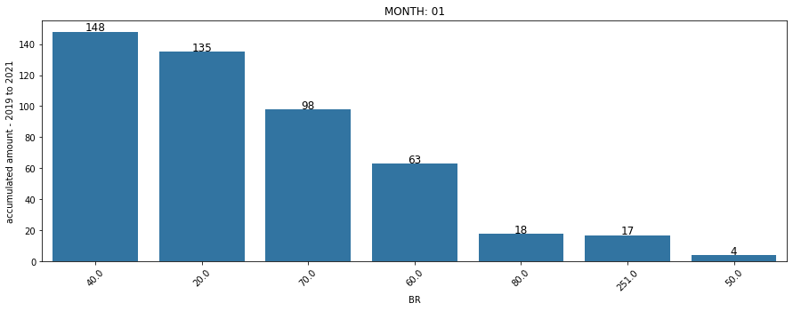

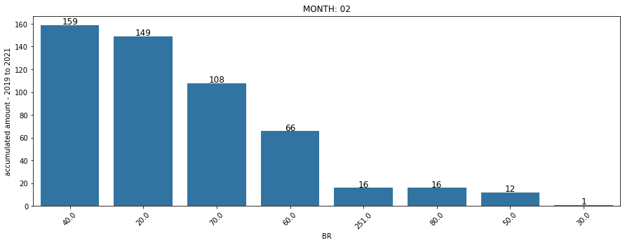

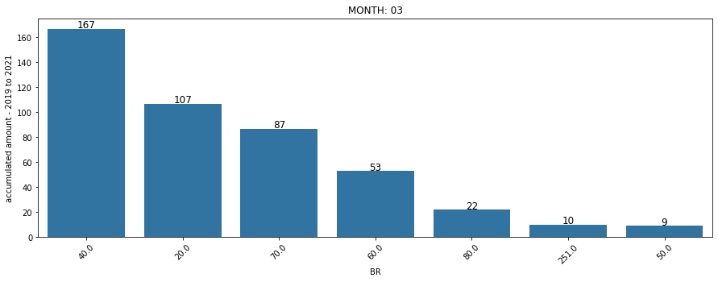

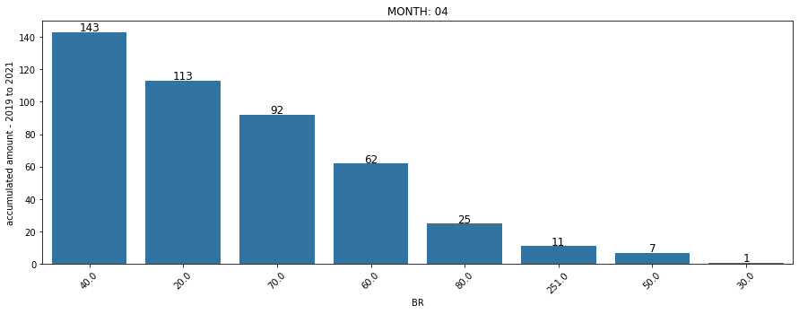

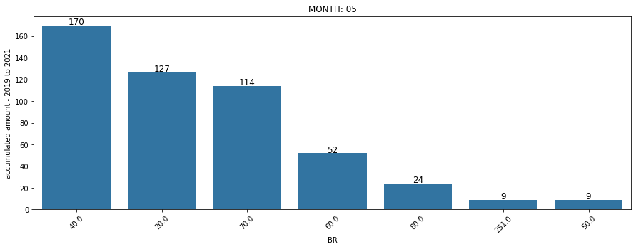

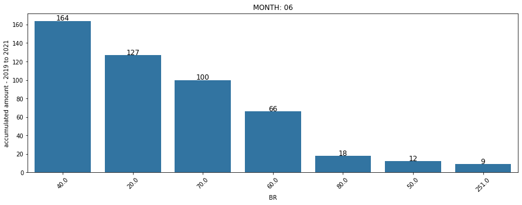

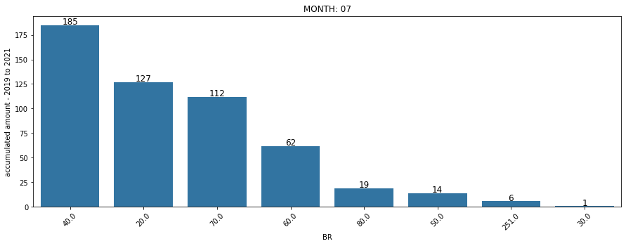

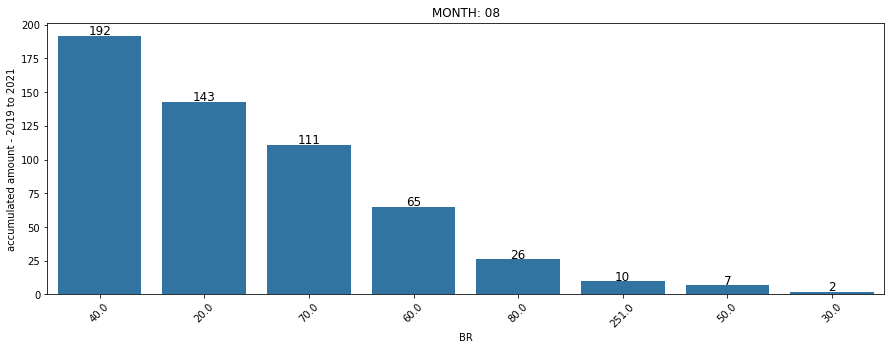

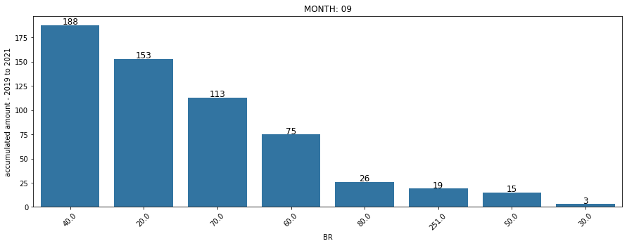

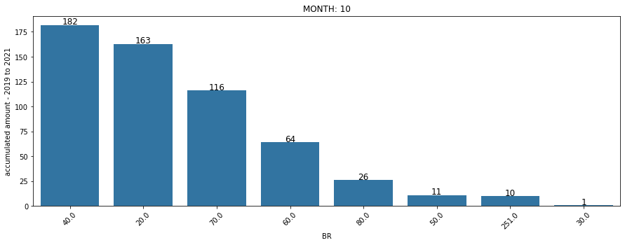

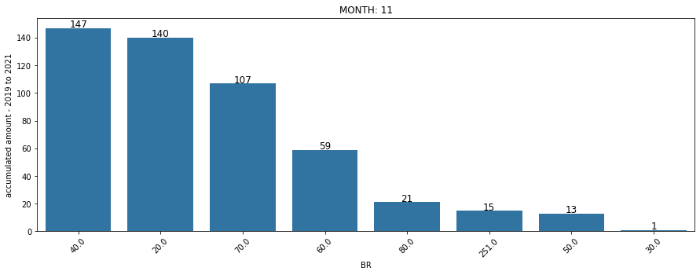

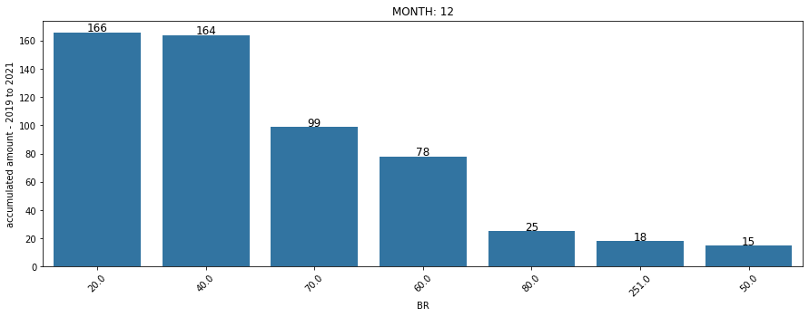

```python
# Monthly ranking of accumulated accidents
base_color = sb.color_palette()[0]
lista_mes = {'01': 'janeiro', '02': 'fevereiro', '03': 'marco', '04': 'abril', '05': 'maio', '06': 'junho',
             '07': 'julho', '08': 'agosto', '09': 'setembro', '10': 'outubro', '11': 'novembro', '12': 'dezembro'}
for mes in lista_mes:
    valor = new_df[new_df['mes'] == mes]
    brs = valor['br'].value_counts().index
    plt.figure(figsize=(15, 5))
    plot = sb.countplot(data=valor, x='br', order=brs, color=base_color)
    plt.xticks(rotation=45)
    plt.title(f'MONTH: {mes}')
    plt.xlabel('BR')
    plt.ylabel('accumulated amount - 2019 to 2021')
    for i in plot.patches:
        plot.annotate(i.get_height(),
                      (i.get_x() + i.get_width() / 2, i.get_height()),
                      ha='center',
                      va='baseline',
                      fontsize=12,
                      color='black',
                      xytext=(0, 1),
                      textcoords='offset points')
    plt.show();
```

### Accident location

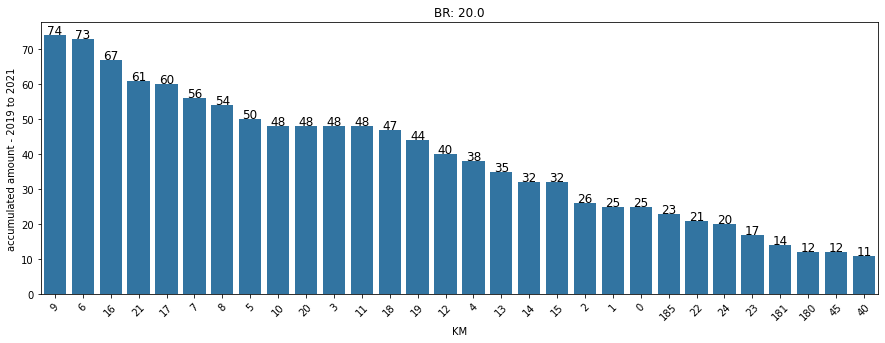

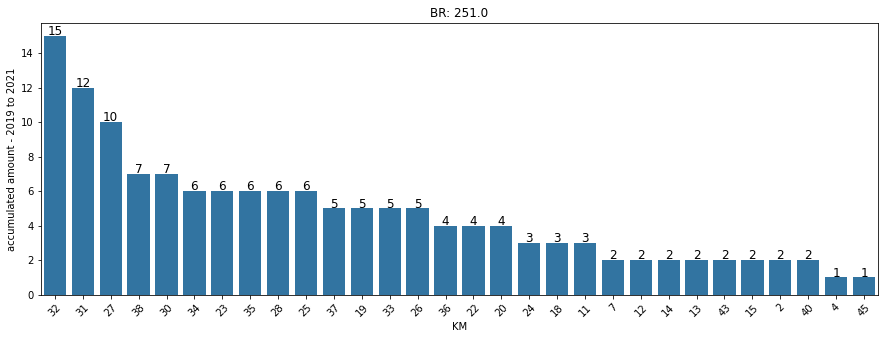

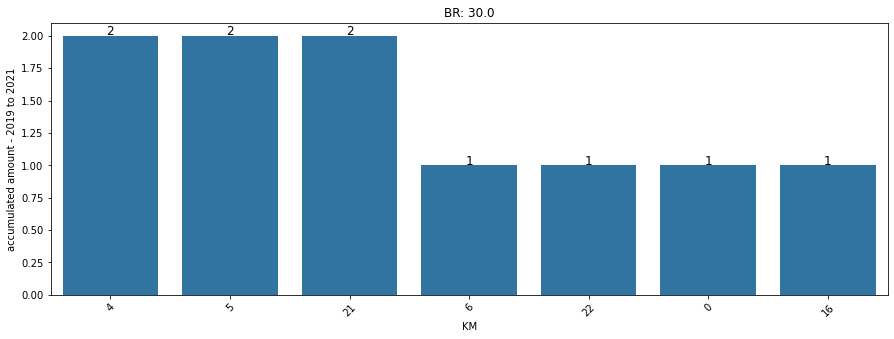

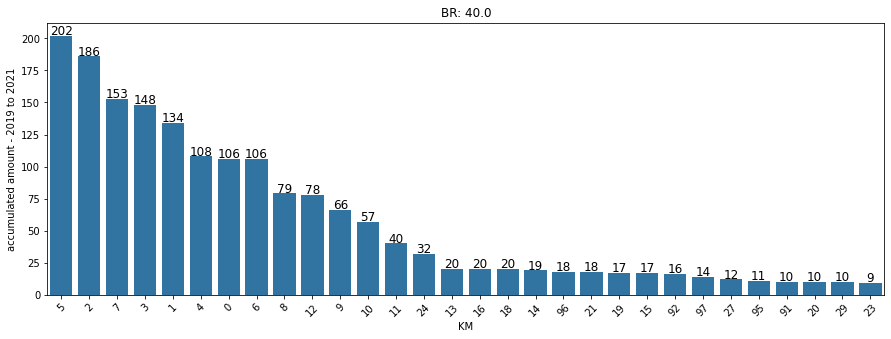

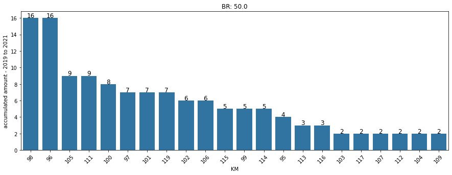

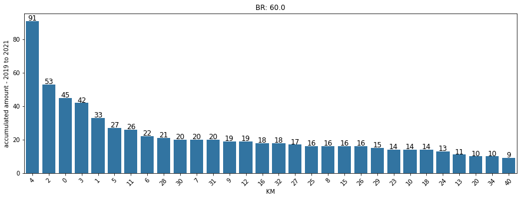

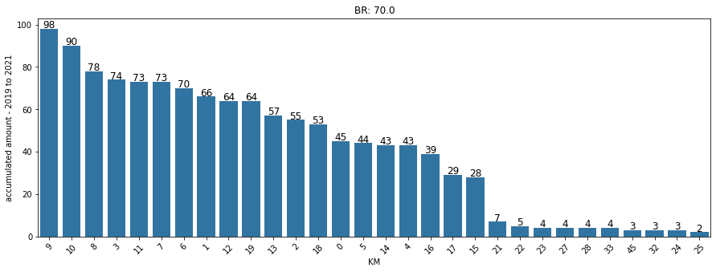

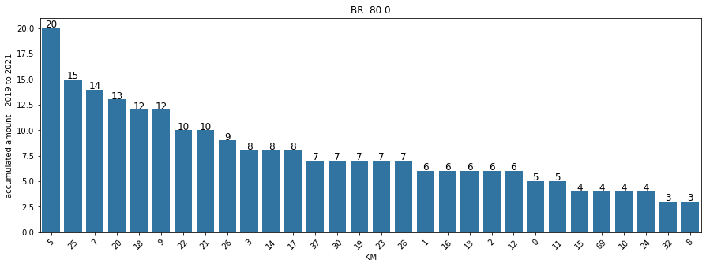

```python
# Accident location in each BR
lista_br = new_df['br'].value_counts().index.sort_values()
base_color = sb.color_palette()[0]
for br in lista_br:
    kmfoco = new_df[new_df['br'] == br]
    order = kmfoco['km'].value_counts().index[:30]
    plt.figure(figsize=(15, 5))
    plot = sb.countplot(data=kmfoco, x='km', order=order, color=base_color)
    plt.xticks(rotation=45)
    plt.title(f'BR: {br}')
    plt.xlabel('KM')
    plt.ylabel('accumulated amount - 2019 to 2021')
    for i in plot.patches:
        plot.annotate(i.get_height(),
                      (i.get_x() + i.get_width() / 2, i.get_height()),
                      ha='center',
                      va='baseline',
                      fontsize=12,
                      color='black',
                      xytext=(0, 1),
                      textcoords='offset points')
    plt.show();
```